# Wine Quality Analysis

Swastik Bhowmick

2023-09-27

# Dataset

Here we have worked on a dataset which is based on the quality of the Portuguese **Vinho Verde** wine, taken from https://www.kaggle.com/datasets/uciml/red-wine-quality-cortez-et-al-2009.

# Objective

Here , we want to predict the quality of wine, ie whether a particular wine is good or bad using logistic regression based on the vales of the covariates in the dataset.

Before beginning our analysis, we call the following libraries.

```r
library(tidyverse)
library(ggcorrplot)
library(grid)
library(car)
library(gridExtra)
library(caTools)
library(caret)
library(class)
library(performance)
library(glue)
library(pROC)
library(Metrics)
```

# Data Description

These are the features in the dataset.

```r
d=read.csv("E:/logistic/WineQuality.csv")
glimpse(d)
```

```
## Rows: 6,497
## Columns: 13
## $ type                 <chr> "white", "white", "white", "white", "white", "whi…
## $ fixed.acidity        <dbl> 7.0, 6.3, 8.1, 7.2, 7.2, 8.1, 6.2, 7.0, 6.3, 8.1,…
## $ volatile.acidity     <dbl> 0.27, 0.30, 0.28, 0.23, 0.23, 0.28, 0.32, 0.27, 0…
## $ citric.acid          <dbl> 0.36, 0.34, 0.40, 0.32, 0.32, 0.40, 0.16, 0.36, 0…
## $ residual.sugar       <dbl> 20.70, 1.60, 6.90, 8.50, 8.50, 6.90, 7.00, 20.70,…
## $ chlorides            <dbl> 0.045, 0.049, 0.050, 0.058, 0.058, 0.050, 0.045, …
## $ free.sulfur.dioxide  <dbl> 45, 14, 30, 47, 47, 30, 30, 45, 14, 28, 11, 17, 1…
## $ total.sulfur.dioxide <dbl> 170, 132, 97, 186, 186, 97, 136, 170, 132, 129, 6…
## $ density              <dbl> 1.0010, 0.9940, 0.9951, 0.9956, 0.9956, 0.9951, 0…
## $ pH                   <dbl> 3.00, 3.30, 3.26, 3.19, 3.19, 3.26, 3.18, 3.00, 3…
## $ sulphates            <dbl> 0.45, 0.49, 0.44, 0.40, 0.40, 0.44, 0.47, 0.45, 0…
## $ alcohol              <dbl> 8.8, 9.5, 10.1, 9.9, 9.9, 10.1, 9.6, 8.8, 9.5, 11…
## $ quality              <int> 6, 6, 6, 6, 6, 6, 6, 6, 6, 6, 5, 5, 5, 7, 5, 7, 6…
```

# Exploratory Data Analysis

Here, we are interested in working with the white variant of the Portuguese **Vinho Verde** wine, hence we have to take a subset of the data accordingly.

```r
d1=d%>%filter(type=="white")%>%select(-type)
```

Then we check for the missing values in the dataset.

```r
colSums(is.na(d1))
```

```
##        fixed.acidity     volatile.acidity          citric.acid
##                    8                    7                    2
##       residual.sugar            chlorides  free.sulfur.dioxide
##                    2                    2                    0
## total.sulfur.dioxide              density                   pH
##                    0                    0                    7
##            sulphates              alcohol              quality
##                    2                    0                    0
```

Here we replace the missing values by the respective means of those variables.

```r
all_column_mean <- apply(d1, 2, mean, na.rm=TRUE)
for(i in colnames(d1))
  d1[,i][is.na(d1[,i])] <- all_column_mean[i]
```

Now we have a dataset containing only white wine and without any missing values. Now in order to apply logistic regression, we transform the response variable that is **quality** of the wine into a binary variable which takes value 1if rating is greater than 5 and 0 otherwise.

```r
d1=d1%>%mutate(qual= ifelse(quality>5,1,0))%>%select(-quality)
```

Let us do the count plot of the response variable

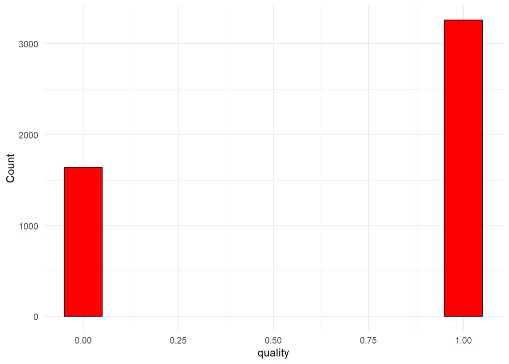

```r
d1 %>% count(qual) %>%
  ggplot(aes(x = qual, y = n)) + geom_col(fill ='red',colour = 'black',  width = 0.1) +
  labs(y = 'Count',x="quality") +
  theme_minimal()
```

Now we will do some visualization of the distribution of each covariate with respect to the quality of wine. First we do the boxplot of the variables.

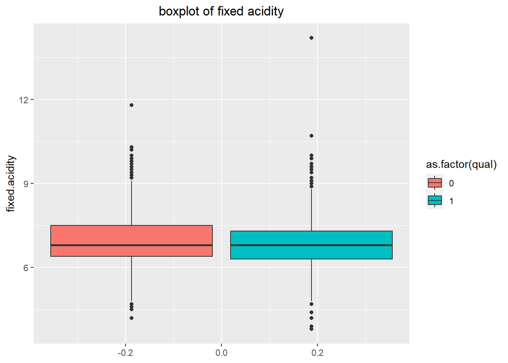

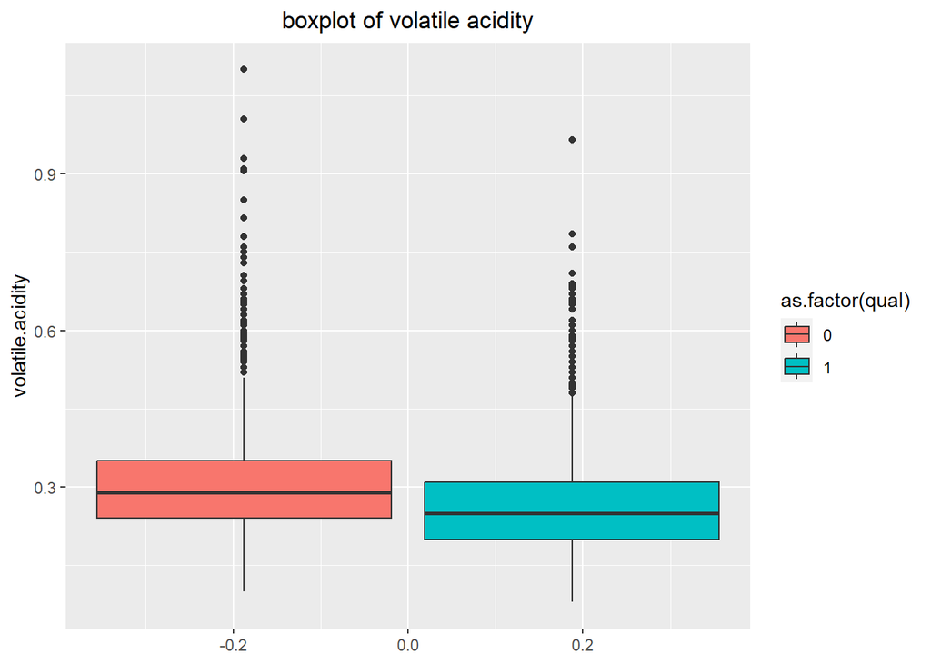

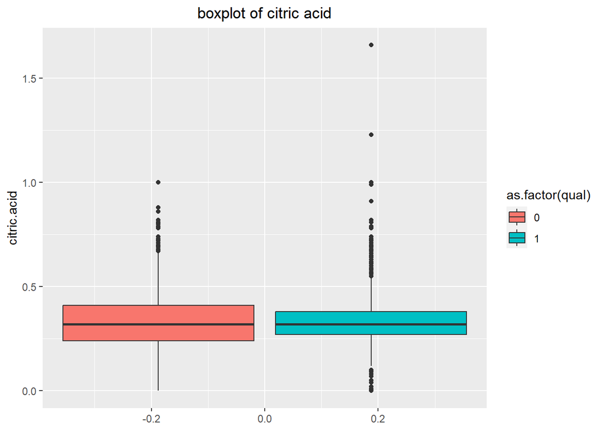

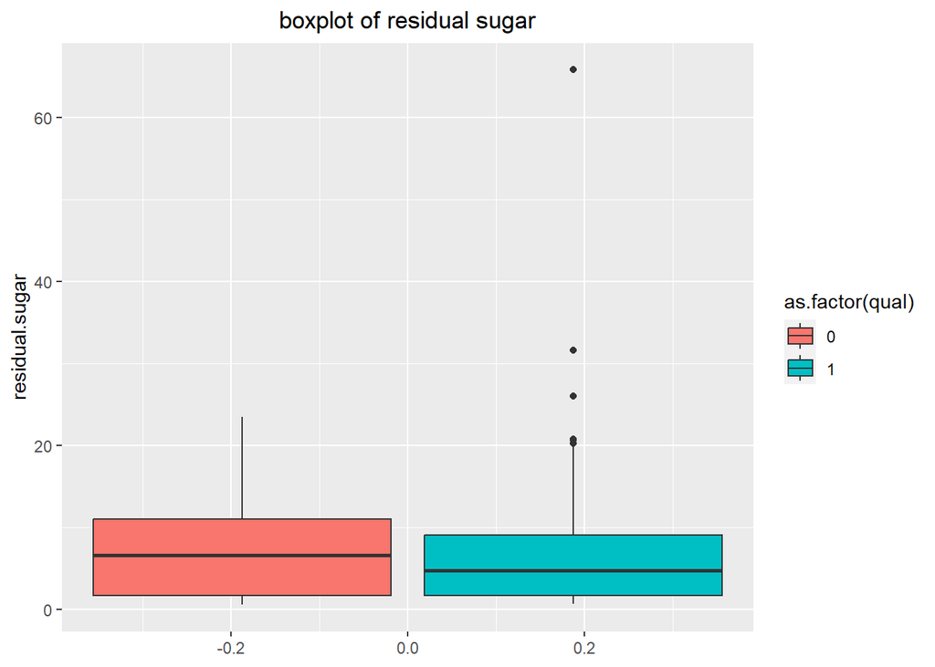

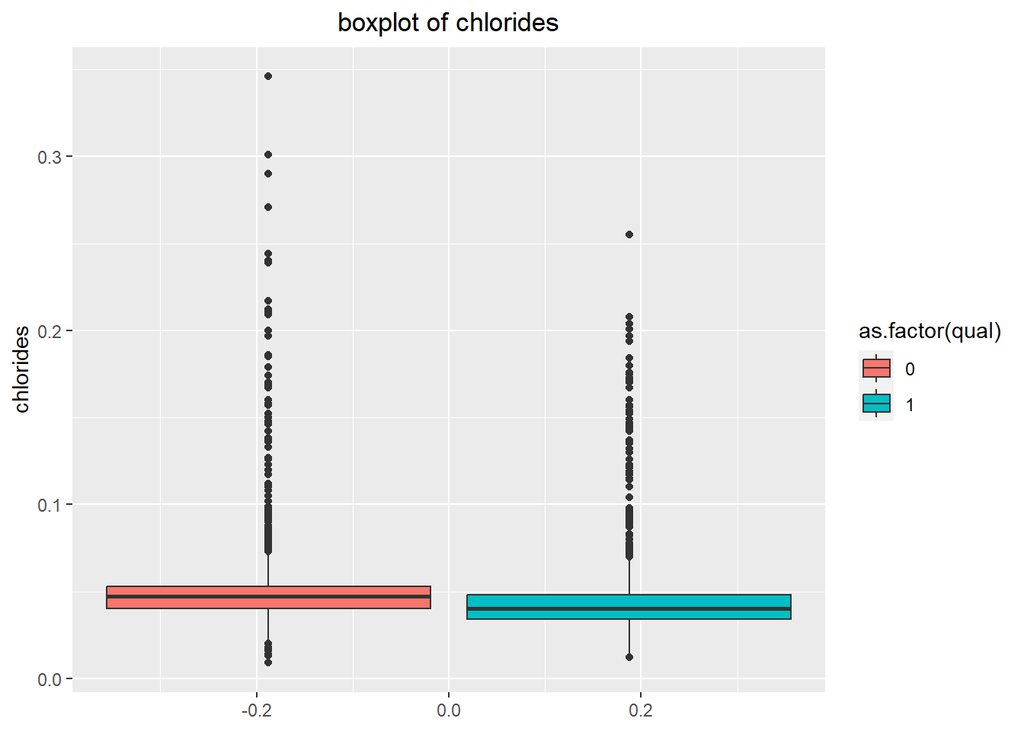

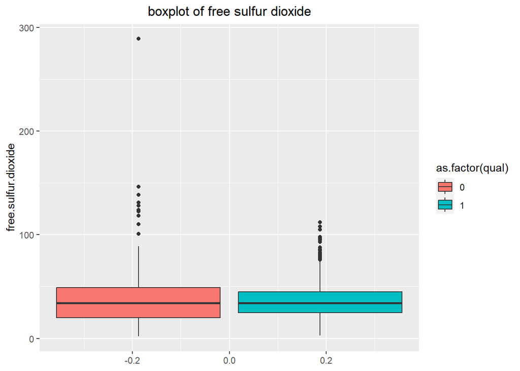

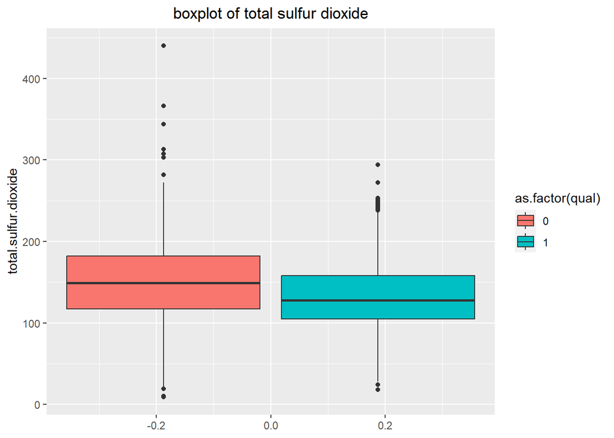

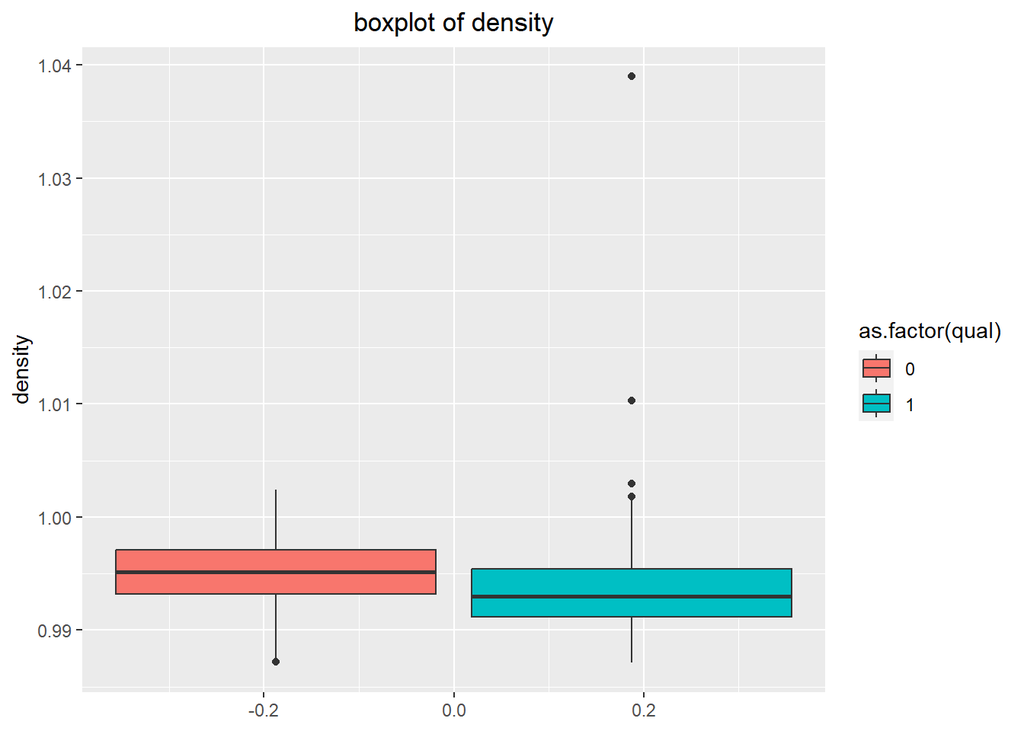

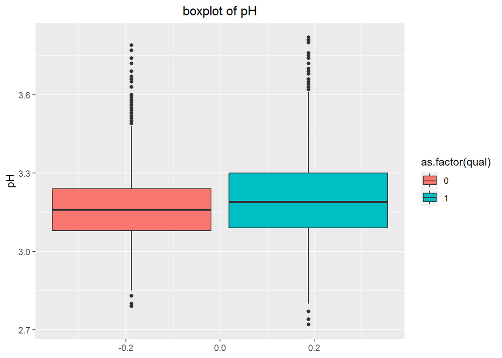

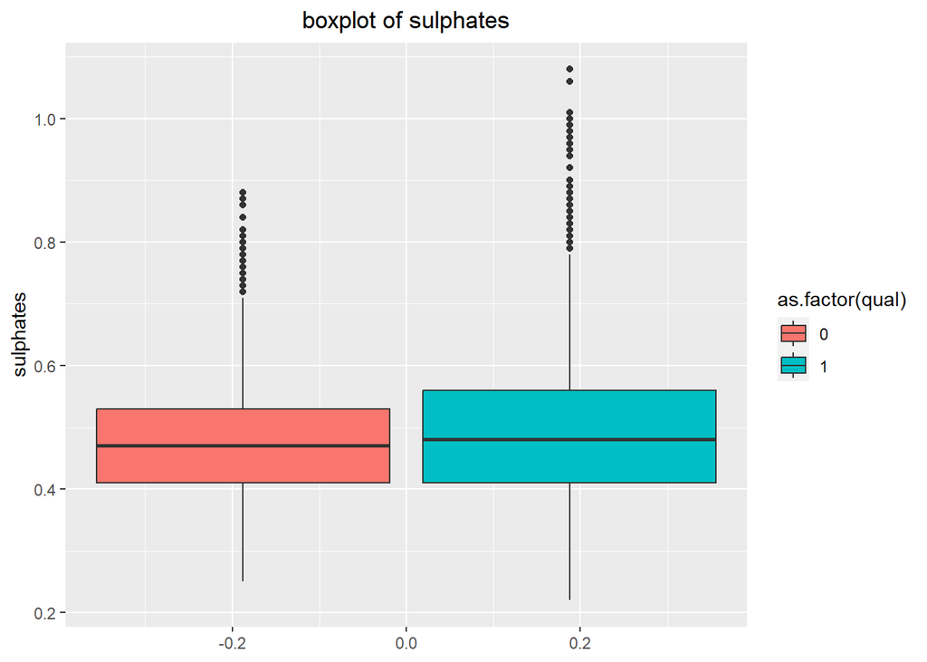

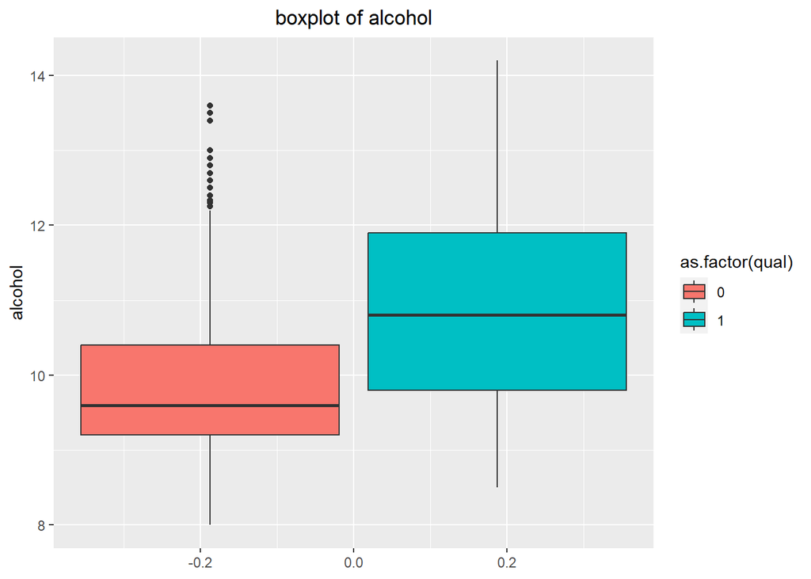

```r
ggplot(data=d1,aes(fill=as.factor(qual),y=fixed.acidity))+geom_boxplot()+ggtitle("boxplot of fixed acidity")+theme(plot.title=element_text(hjust=0.5))
```

*Comment:* Say, for example, we take the distribution of alcohol with respect to quality of wine. Here, we can observe that as the alcohol quantity increases, the quality of wine tends to be good. We can make similiar observations regarding other covariates with respect the quality of wine as well.

Now, let us plot the correlations between the variables using a correlation heatmap.

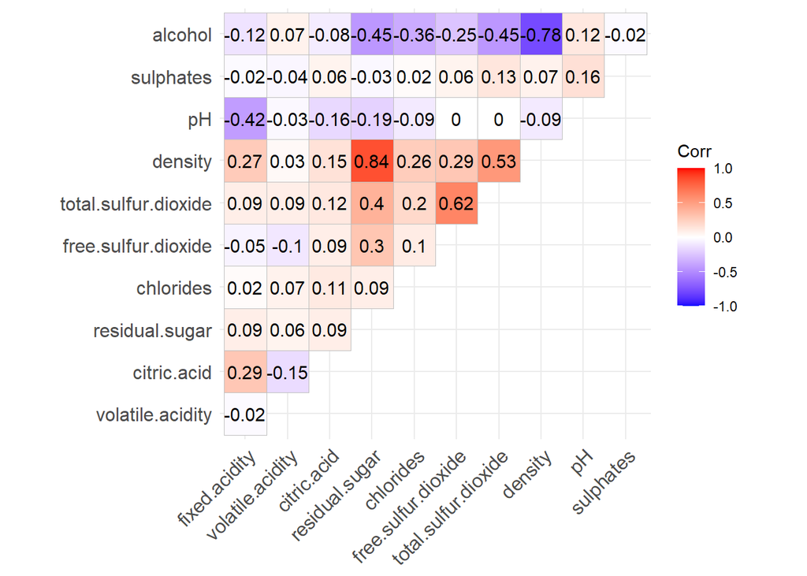

```r
d1%>%select(-qual)%>%cor()%>%ggcorrplot(lab=T,type="upper")
```

The heatmap indicates that there multicollinearity present in the data. To check which of the predictors are responsible for it, we go for checking variance inflation factor.

Before applying vif, we split the dataset into training and testing sets.

```r
set.seed(48)
d1$id=1:nrow(d1)
train=d1%>%sample_frac(0.75)
test=anti_join(d1,train,by='id')
train=train%>%select(-id)
test=test%>%select(-id)
```

Now we check for multicollinearity in the training data.

```r
m=glm(qual~.,data=train,family=binomial(link="logit"))
vif(m)
```

```
##        fixed.acidity     volatile.acidity          citric.acid
##             2.916382             1.163858             1.163629
##       residual.sugar            chlorides  free.sulfur.dioxide
##            15.901536             1.201289             1.832105
## total.sulfur.dioxide              density                   pH
##             2.218796            30.752387             2.332823
##            sulphates              alcohol
##             1.157475             6.939010
```

It is evident that `density` has the highest vif that is why we remove it from the model.

Let see the vifs after removing `density`.

```r
m1=glm(qual~.,data=train%>%select(-density),family=binomial(link="logit"))
vif(m1)
```

```
##        fixed.acidity     volatile.acidity          citric.acid
##             1.309563             1.165672             1.151295
##       residual.sugar            chlorides  free.sulfur.dioxide
##             1.548806             1.164135             1.795246
## total.sulfur.dioxide                   pH            sulphates
##             2.111738             1.317355             1.071554
##              alcohol
##             1.746050
```

The vifs of all of the variables have removed significantly after the removal of `density` from the model.

Let take a look at the summary table of the model.

```r
summary(m1)
```

```
##
## Call:
## glm(formula = qual ~ ., family = binomial(link = "logit"), data = train %>%
##     select(-density))
##
## Deviance Residuals:
##     Min       1Q   Median       3Q      Max
## -2.7161  -0.8765   0.4230   0.7809   2.5478
##
## Coefficients:
##                       Estimate Std. Error z value Pr(>|z|)
## (Intercept)          -9.583817   1.314138  -7.293 3.03e-13 ***
## fixed.acidity        -0.201659   0.054414  -3.706 0.000211 ***
## volatile.acidity     -7.177987   0.490599 -14.631  < 2e-16 ***
## citric.acid           0.131381   0.348244   0.377 0.705976
## residual.sugar        0.083089   0.009581   8.672  < 2e-16 ***
## chlorides             1.290836   1.980929   0.652 0.514639
## free.sulfur.dioxide   0.011898   0.003249   3.663 0.000250 ***
## total.sulfur.dioxide -0.001958   0.001387  -1.412 0.157806
## pH                    0.155181   0.310831   0.499 0.617606
## sulphates             1.255189   0.399248   3.144 0.001667 **
## alcohol               1.139226   0.053251  21.394  < 2e-16 ***
## ---
## Signif. codes:  0 '***' 0.001 '**' 0.01 '*' 0.05 '.' 0.1 ' ' 1
##
## (Dispersion parameter for binomial family taken to be 1)
##
##     Null deviance: 4703.5  on 3673  degrees of freedom
## Residual deviance: 3635.8  on 3663  degrees of freedom
## AIC: 3657.8
##
## Number of Fisher Scoring iterations: 5
```

The p values of the predictors `citric acid,chlorides` and `pH` are larger than 0.05, hence these predictors are not significant in predicting the quality of wine. So we drop them from the model.

```r
m2=glm(qual~.,data=train%>%select(-c(density,citric.acid,chlorides,pH)),family=binomial(link="logit"))
summary(m2)
```

```
##
## Call:
## glm(formula = qual ~ ., family = binomial(link = "logit"), data = train %>%
##     select(-c(density, citric.acid, chlorides, pH)))
##
## Deviance Residuals:
##     Min       1Q   Median       3Q      Max
## -2.7222  -0.8741   0.4225   0.7804   2.5360
##
## Coefficients:
##                       Estimate Std. Error z value Pr(>|z|)
## (Intercept)          -8.860791   0.681582 -13.000  < 2e-16 ***
## fixed.acidity        -0.208278   0.048147  -4.326 1.52e-05 ***
## volatile.acidity     -7.182390   0.483467 -14.856  < 2e-16 ***
## residual.sugar        0.081404   0.009285   8.767  < 2e-16 ***
## free.sulfur.dioxide   0.011940   0.003239   3.686 0.000228 ***
## total.sulfur.dioxide -0.001862   0.001376  -1.353 0.176140
## sulphates             1.291019   0.393080   3.284 0.001022 **
## alcohol               1.129597   0.050428  22.400  < 2e-16 ***
## ---
## Signif. codes:  0 '***' 0.001 '**' 0.01 '*' 0.05 '.' 0.1 ' ' 1
##
## (Dispersion parameter for binomial family taken to be 1)
##
##     Null deviance: 4703.5  on 3673  degrees of freedom
## Residual deviance: 3636.6  on 3666  degrees of freedom
## AIC: 3652.6
##
## Number of Fisher Scoring iterations: 5
```

Now we proceed to find the optimal threshold probability for classifying wine into good or bad.

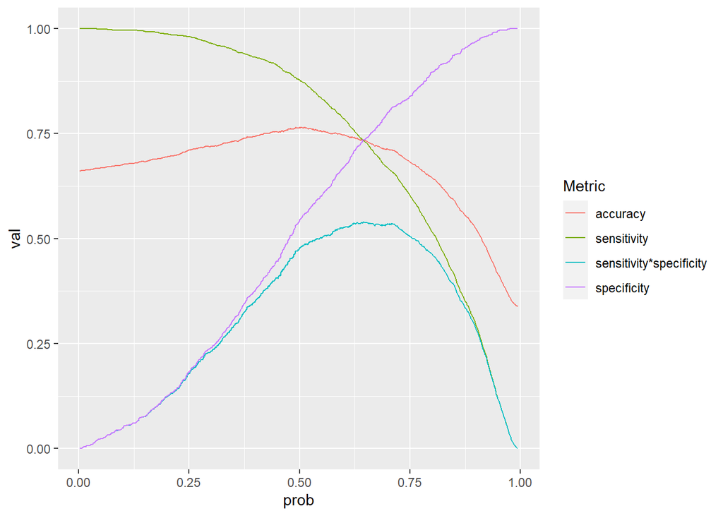

```r
y_train=train$qual
p1=predict(m1,type="response")
metric=function(a){
   Y_i_hat=ifelse(p1>=a,1,0)
    sens=length(y_train[Y_i_hat==1&y_train==1])/length(y_train[y_train==1])
    spec=length(y_train[Y_i_hat==0&y_train==0])/length(y_train[y_train==0])
    acc=length(y_train[(Y_i_hat==1&y_train==1)|(Y_i_hat==0&y_train==0)])/length(y_train)
    return(c(sens,spec,acc,sens*spec))
}
M=matrix(0,nrow=length(sort(p1)),ncol=4)
for(i in 1:length(p1)){
  M[i,]=metric(sort(p1)[i])
}
Metric=rep(c("sensitivity","specificity","accuracy","sensitivity*specificity"),each=length(p1))
val=array(M)
prob=rep(sort(p1),4)
metric_d=data.frame(Metric,val,prob)
ggplot(data=metric_d,aes(x=prob,y=val,colour=Metric))+geom_line()
```

Here we have plotted the values of accuracy,sensitivity, specificity ,accuracy and the product of specificity and sensitivity vs the predicted probabilities.

The threshold probability that value where the product specificity and sensitivity is highest. It is given by

```r
t_p=sort(p1)[M[,4]==max(M[,4])];t_p
```

```
##       266
## 0.6309214
```

The roc curve is given as follows:-

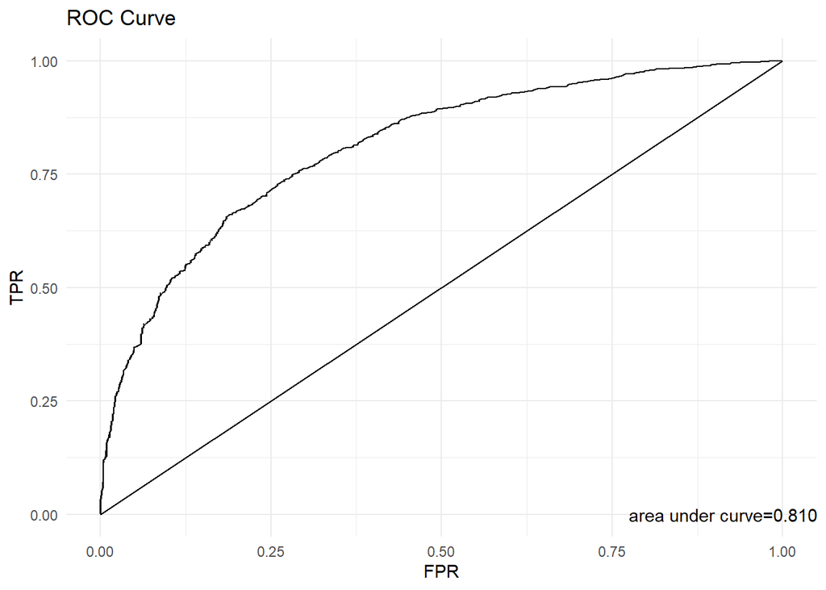

```r
y_pred=ifelse(p1>t_p,1,0)
rocobj=roc(y_train,p1)
roc1=data.frame("TPR"=M[,1],"FPR"=1-M[,2])
ggplot(roc1,aes(x=FPR,y=TPR))+geom_line()+geom_segment(x=0,y=0,xend=1,yend=1)+ggtitle("ROC Curve")+annotate("text",label=glue("area under curve={pROC::auc(rocobj)}"),x=1,y=0)+theme_minimal()
```

The assosciated confusion matrix is given by

```r
cm=confusionMatrix(data=factor(y_pred),reference=factor(y_train))
M1=as.matrix(cm$table);M1
```

```
##           Reference
## Prediction    0    1
##          0  895  610
##          1  349 1820
```

The performance metrics are given below

```r
accuracy=sum(diag(M1))/sum(M1);accuracy
```

```
## [1] 0.7389766
```

```r
precision=M1[2,2]/sum(M1[2,]);precision
```

```
## [1] 0.8390964
```

```r
recall=M1[2,2]/sum(M1[,2]);recall
```

```
## [1] 0.7489712
```

```r
f1_score=(2*precision*recall)/(precision+recall);f1_score
```

```
## [1] 0.7914764
```

# Test Data Analysis

After fitting the model on the training data, we see how the model works on unforeseen data, ie on the test data. We will compare the actual and predicted values of the wine quality and compare them with a confusion matrix.

```r
p2=predict.glm(m1,newdata=test,type="response")
y_t_p=ifelse(p2>=t_p,1,0)
y_test=test$qual
cm1=confusionMatrix(data=factor(y_t_p),reference=factor(y_test))
M2=as.matrix(cm1$table)
accuracy1=sum(diag(M2))/sum(M2);accuracy1
```

```
## [1] 0.6936275
```

```r
precision1=M2[2,2]/sum(M2[2,]);precision1
```

```
## [1] 0.8221906
```

```r
recall1=M2[2,2]/sum(M2[,2]);recall1
```

```
## [1] 0.6980676
```

```r
f1_score1=(2*precision1*recall1)/(precision1+recall1);f1_score1
```

```
## [1] 0.7550621
```

Now we will construct the ROC curve for the testing data

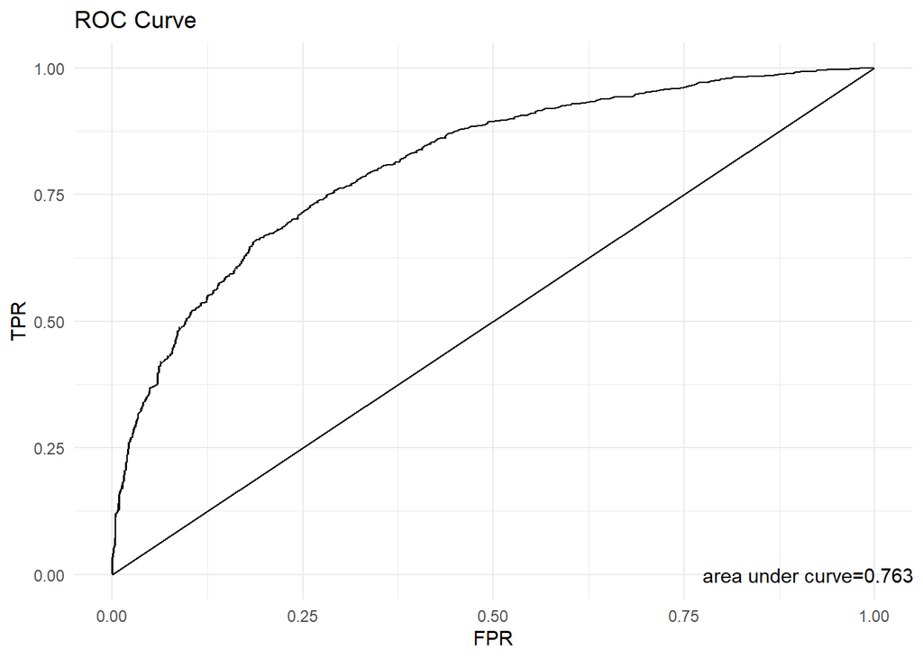

```r
M3=matrix(0,ncol=4,nrow=length(p2))
for( i in 1:length(p2)){
  M3[i,]=metric(sort(p1)[i])
}
rocobj1=roc(y_test,p2)
roc2=data.frame("TPR"=M[,1],"FPR"=1-M[,2])
ggplot(roc2,aes(x=FPR,y=TPR))+geom_line()+geom_segment(x=0,y=0,xend=1,yend=1)+ggtitle("ROC Curve")+annotate("text",label=glue("area under curve={pROC::auc(rocobj1)}"),x=1,y=0)+theme_minimal()
```

The area under curve for the testing dataset is $0.763$, which implies that the model works well even on the unforseen data, which shows that the fit is good.